# Clinical Coding Changes over time

Victoria Best

22 September 2021

## Aims

This report investigates the clinical coding of records within the SAIL hospital admissions dataset (PEDW), by comparing records prior to, and post COVID-19. The purpose is to understand what impact, if any, COVID-19 has had on clinical coding, as well as any impact data lag will have upon analysis of PEDW data and resultant findings.

The following two hypotheses were investigated using ICD-10 and OPCS-4 codes within the PEDW data

- Whether all clinical coding has declined since the COVID-19 outbreak
- Whether clinical coding has declined in only certain coding Chapters

Unless otherwise specified, references to episodes includes all episodes, regardless of their coding status. Where a distinction is made the following definitions are used throughout the report:

- Coded episodes: episodes with a valid primary ICD-10 code recorded within the PEDW episodes dataset
- Uncoded episodes: episodes where the primary ICD-10 code is null within the PEDW episodes dataset

## Key Output Summary

Table 1: Percentage of Episodes With Primary ICD-10 Coding by Month of Episode End

| Episode End Date | Time Period | Percentage Coded (7 day rollavg) |
| --- | --- | --- |
| 2021-07-27 | Latest Episode End | NA |
| 2021-07-20 | 1 Week Prior | 17% |
| 2021-07-13 | 2 Weeks Prior | 29% |
| 2021-07-06 | 3 Weeks Prior | 39% |
| 2021-06-27 | 1 Month Prior | 67% |
| 2021-05-27 | 2 Months Prior | 80% |
| 2021-04-27 | 3 Months Prior | 86% |
| 2021-03-27 | 4 Months Prior | 91% |
| 2021-02-27 | 5 Months Prior | 94% |
| 2021-01-27 | 6 Months Prior | 96% |

Table 2: Percentage of Episodes With Primary OPCS-4 Coding by Month of Episode End

| Episode End Date | Time Period | Percentage Coded (7 day rollavg) |
| --- | --- | --- |
| 2021-07-27 | Latest Episode End | NA |
| 2021-07-20 | 1 Week Prior | 12% |
| 2021-07-13 | 2 Weeks Prior | 19% |
| 2021-07-06 | 3 Weeks Prior | 25% |
| 2021-06-27 | 1 Month Prior | 44% |
| 2021-05-27 | 2 Months Prior | 51% |
| 2021-04-27 | 3 Months Prior | 54% |
| 2021-03-27 | 4 Months Prior | 57% |
| 2021-02-27 | 5 Months Prior | 58% |
| 2021-01-27 | 6 Months Prior | 60% |

## Methods and data considerations

PEDW data extracts used for this report are taken on a monthly basis. This report uses the following data reports and tables:

- SAIL0572V.PEDW_EPISODE_20210801
- SAIL0572V.PEDW_SPELL_20210801
- SAIL0572V.PEDW_DIAG_20210801
- SAIL0572V.PEDW_OPER_20210801
- SAIL0572V.ADDE_DEATHS_20210728
- SAILUKHDV.ICD10_CODES_AND_TITLES_AND_METADATA_20210803 (linked to version 5)
- OPCS4_CODES_AND_TITLES_20210803 (linked to version 4.9)

The starting point for analysis was the PEDW episodes data for episodes with an end date from April 2016. Episode counts quoted in this report are row counts from the PEDW episodes extract. It should be noted that a single hospital spell may contain multiple episodes with different primary diagnosis and operational coding.

Where counts are fewer than 5, the values are suppressed to prevent possible disclosure.

Summary of data exclusions:

- Episodes where data linkage was not sufficiently robust (anonymised linking field status threshold 1, 4 or 39 was not met, see appendix 9 for matching status definitions)
- Episodes with a sensitive diagnosis or operational procedure codes as defined within the SAIL disclosure rules.
- Episodes where the care provider was not one of the seven Welsh Health Boards or Velindre NHS Trust
- Episodes where the ADDE Deaths record indicated a date of death prior to the episode start date

Unfinished episodes are not included in the main dataset for analysis because the records are incomplete. In total there were 8,051 unfinished episodes, with the earliest from 2001. Since April 2016 there were 7,995, representing 0.13% of all episodes. Further information is available in Appendix 4.

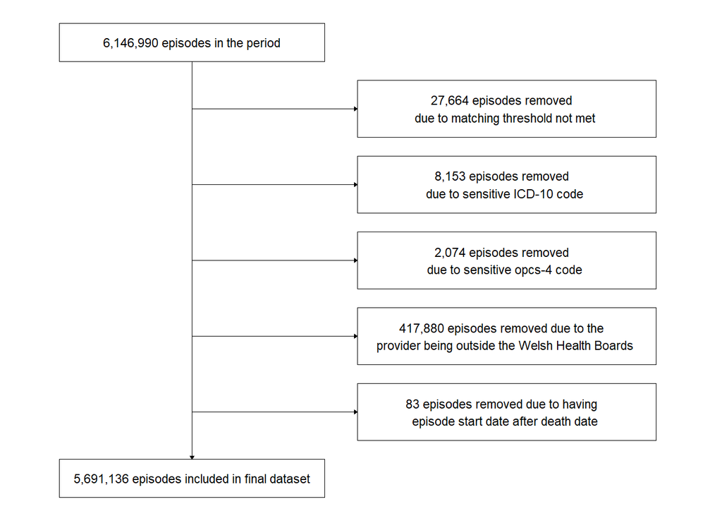

**Figure 1.** CONSORT diagram for episodes included in the analysis

## Background

According to the BMA (2020), in “order to free up enough capacity to deal with the initial peak of the pandemic, the NHS was forced to shut down or significantly reduce many areas of non-COVID-19 care during April, May and June 2020. This, combined with fewer patients seeking care during lockdown, means that there has been a significant drop in elective procedures, urgent cancer referral, first cancer treatments and outpatient appointments.” This will impact not only the overall number of episodes recorded, but also very likely the nature of those episodes, as elective procedures are likely to have been more heavily impacted than urgent A&E care.

In addition to the changes in the nature of the procedures provided by the NHS since the start of the COVID_19 pandemic, there are further complications due to changes in the clinical coding standards which have needed to rapidly adapt in order to measure the pandemic. This has not only resulted in the addition of several new codes, but has also changed the standards for assigning primary codes.

COVID-19 codes were not made available until 26th March 2020, however it is known that there were cases in the UK prior to this date. There was a requirement for the cases to be retrospectively coded but it is not possible to know how completely this was carried out.

Between the introduction of the COVID-19 codes in late March and 30th June 2020, all episodes which included COVID-19 were required to have COVID-19 recorded as their primary diagnosis. From 1st July 2020, this process was changed to COVID-19 being recorded as the secondary diagnosis, unless it was in fact the primary, as detailed by HSCIC (2021). Any analysis investigating only primary ICD10 codes is therefore likely to be significantly impacted by the standards changes, not only when investigating COVID-19, but also other diagnoses where COVID-19 was present during the episode.

An added complicating factor is that the Welsh Government has recently removed the target of 95% completion for clinical codes. This may have further reduced the completion rates for clinical coding. Despite this change, it is likely that coding relating to COVID-19 episodes will have remained high due to the public interest. This may skew the picture when comparing COVID-19 episodes against others, as it is not known whether some codes are being prioritised over others.

## Findings

### Rolling average episodes

In April the number of episodes recorded reduced by -50% from a previous monthly average of 91,984 to 46,056 being recording in the month. There has since been a recovery in episode numbers, although not to pre COVID-19 levels.

The rolling seven day trend of all episodes shows that there was a sharp reduction in episodes recorded in March, with the lowest rolling average number of episodes occurring on 13 April 2020. The pre-covid daily average was 3,167 which has since reduced to 2,292.

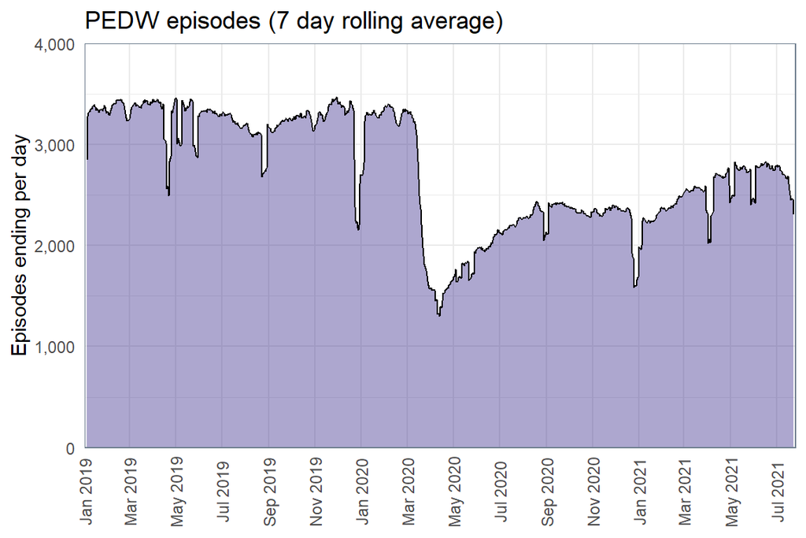

**Figure 2.** PEDW episodes recorded per day based on a seven day rolling average

In January and February 2020, the number of episodes recorded in PEDW was higher than the previous monthly average recorded between 2016 and 2019. However, from March 2020 onwards, the number of episodes recorded reduced to much lower levels than the previous averages, with April showing the greatest reduction (see Table 3).

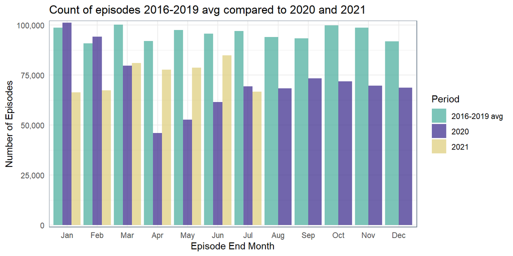

**Figure 3.** Average episodes per month 2016-2019, compared with episodes recorded in 2020

Table 3: Average episodes recorded, 2020 comparison to monthly averages 2016-2019

| Episode End Month | Avg episodes 2016-2019 | Episodes 2020 | Percentage Change |
| --- | --- | --- | --- |
| Jan | 98771 | 101267 | 3% |
| Feb | 90835 | 94228 | 4% |
| Mar | 100269 | 79698 | -21% |
| Apr | 91984 | 46056 | -50% |
| May | 97572 | 52753 | -46% |
| Jun | 95705 | 61573 | -36% |
| Jul | 97002 | 69459 | -28% |
| Aug | 94110 | 68334 | -27% |
| Sep | 93385 | 73389 | -21% |
| Oct | 99950 | 71858 | -28% |
| Nov | 98733 | 69717 | -29% |
| Dec | 91945 | 68738 | -25% |

### Newly added episodes from April 2019

The latest audit into clinical coding, Cracking the Code, Management of Clinical Coding Across Wales (Sep 2020), identifies any episodes not coded within a month as backlog. The report identified over 181,000 backlogged finished consultant episodes (FCEs) from April 2017 to May 2020.

Between the 05 July 2021 PEDW data extract and 02 August 2021 data extract, there were 77,875 new episodes, with episode end dates ranging from April 2016 to July 2021. The majority of these episodes are for the latest month. However, there were 3,330 episodes entered retrospectively since the 05 July 2021 data extract, with the majority of backdated episodes ending in Jun 2021.

Figure 4 shows all backdated episodes newly added in the latest PEDW Episodes report which have episode end dates prior to the end of the previous report. Note that any values fewer than five are reduced to zero to prevent possible disclosure.

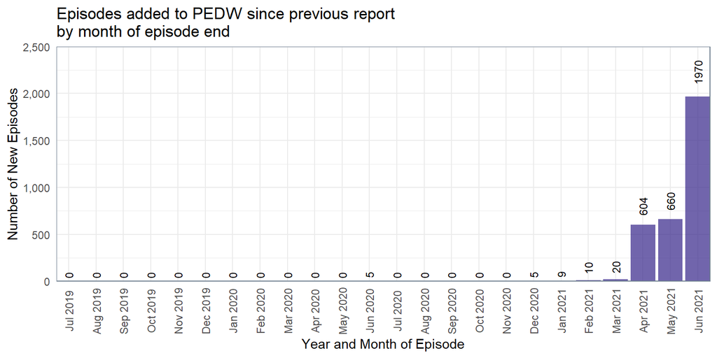

**Figure 4.** Backdated episodes added to PEDW since previous report end date

The mean lag length was 44.34 days, calculated as the average days between the recorded episode end date and the end date of the previous report.

A large number of episodes were retrospectively added within the Cwm Taf Local Health Board in the March 2021 PEDW data extract, covering the period up to March 2019. No large backdating of episodes was seen during the most recent data extract.

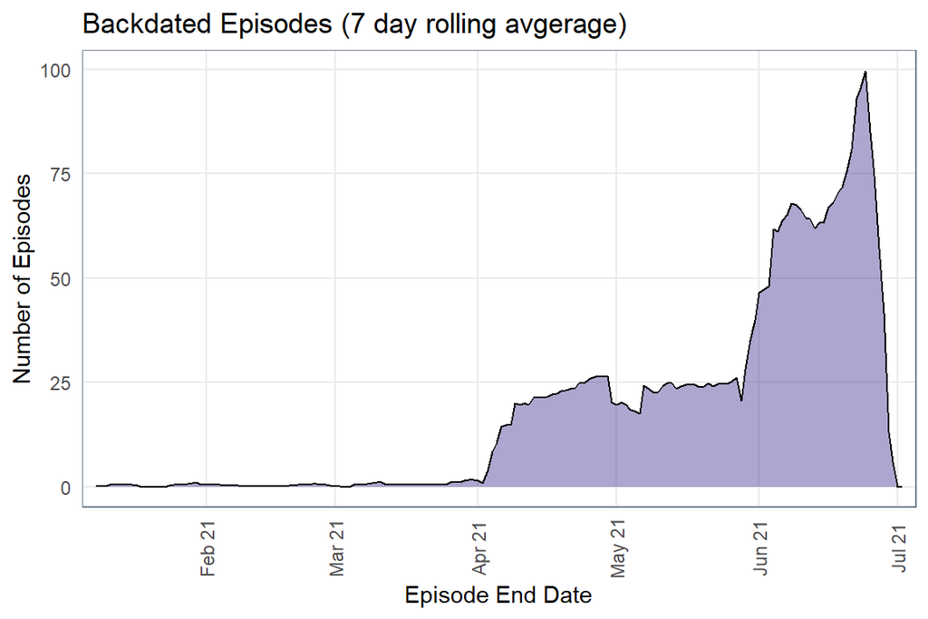

**Figure 5.** Backdated episodes added to PEDW in six months prior to previous report end (7 day rolling average)

The below chart shows the number of episodes ending on a given day. The area shading indicates the first data extract in which the episode was recorded in PEDW.

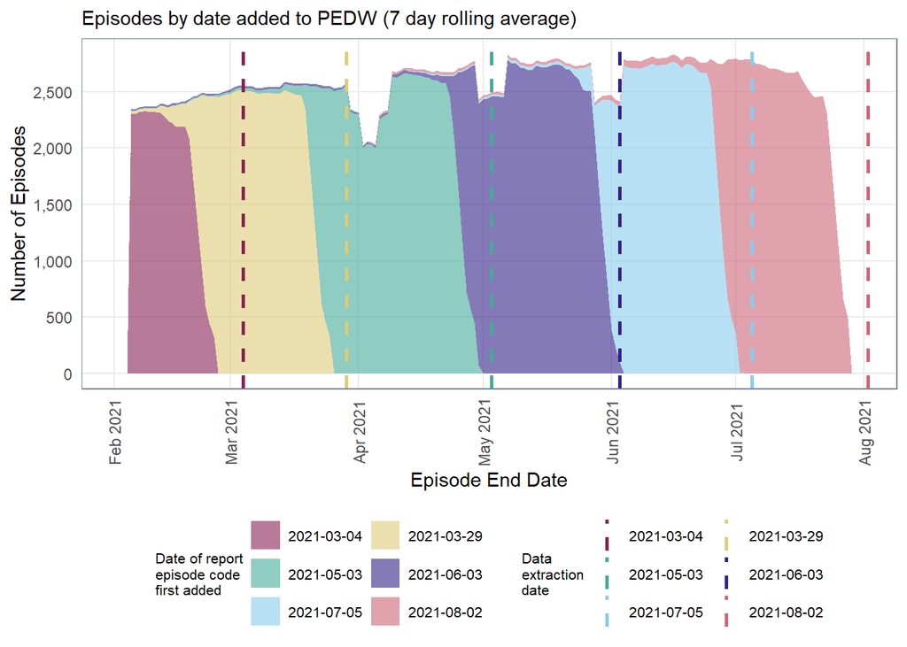

**Figure 6.** Episodes by date added to PEDW (7 day rolling average)

### Uncoded Episodes

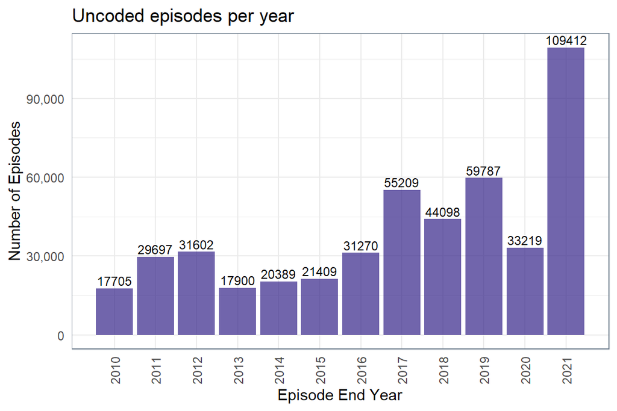

**Figure 7.** Uncoded episodes per year

There are 189,483 uncoded episodes with end dates from April 2019 onwards, distributed across 143,452 spells. Of these, only 3,954 spells (3%) had another coded episode within the same spell.

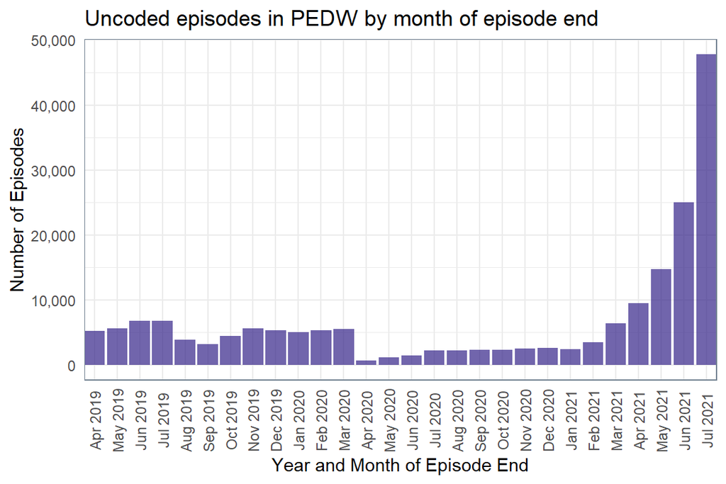

**Figure 8.** Uncoded episodes by month of episode end

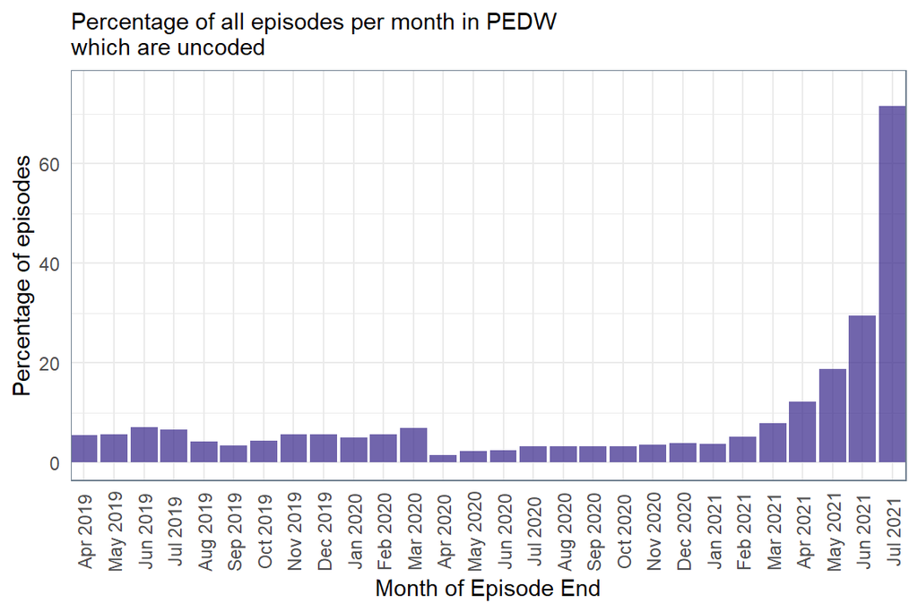

**Figure 9.** Uncoded episodes as a percentage of all episodes

There is a much higher number of uncoded episodes in recent months which is likely due to datalag.

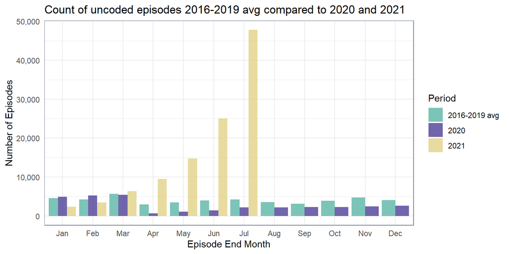

**Figure 10.** Episodes with null ICD-10 code, 2016-2019 average compared to 2020 actual

Due to the high number of uncoded episodes in recent months, the below chart excludes recent months to provide a clearer picture of the difference excluding the biggest impact from datalag.

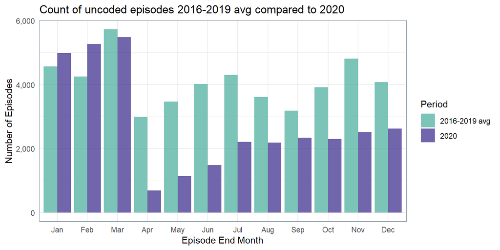

**Figure 11.** Episodes with null ICD-10 code, 2016-2019 average compared to 2020 actual

**Table 4:** Average uncoded episodes recorded, 2020 comparison to monthly averages 2016-2019

| Episode End Month | 2016-19 uncoded | 2020 uncoded | Percentage Change |
| --- | --- | --- | --- |
| Jan | 4562 | 4981 | 9% |
| Feb | 4254 | 5271 | 24% |
| Mar | 5725 | 5482 | -4% |
| Apr | 2992 | 692 | -77% |
| May | 3467 | 1144 | -67% |
| Jun | 4018 | 1483 | -63% |
| Jul | 4301 | 2205 | -49% |
| Aug | 3615 | 2186 | -40% |
| Sep | 3186 | 2337 | -27% |
| Oct | 3913 | 2297 | -41% |
| Nov | 4813 | 2513 | -48% |
| Dec | 4079 | 2624 | -36% |

As there has been a change in the number of episodes recorded in PEDW following COVID-19, the below plot illustrates the proportion of uncoded episodes per month.

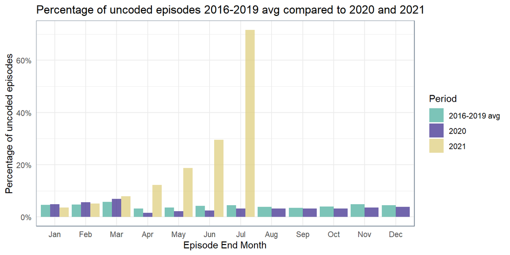

**Figure 12.** Proportion of uncoded episodes

Due to the high proportion of uncoded episodes in recent months, the below chart excludes recent months to provide a clearer picture of the percentage difference excluding the biggest impact from datalag.

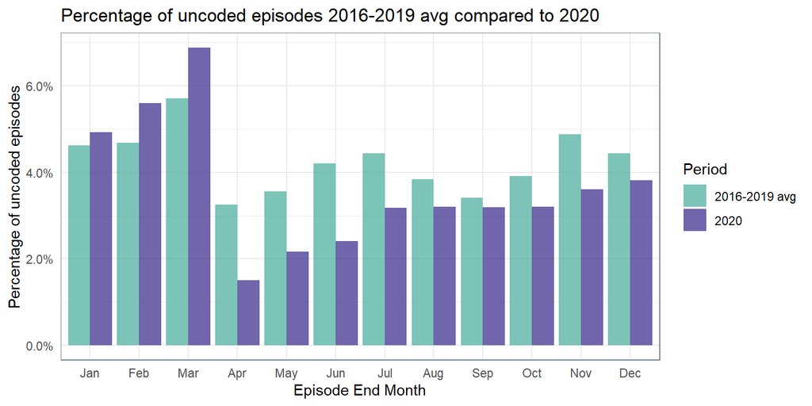

**Figure 13.** Proportion of uncoded episodes

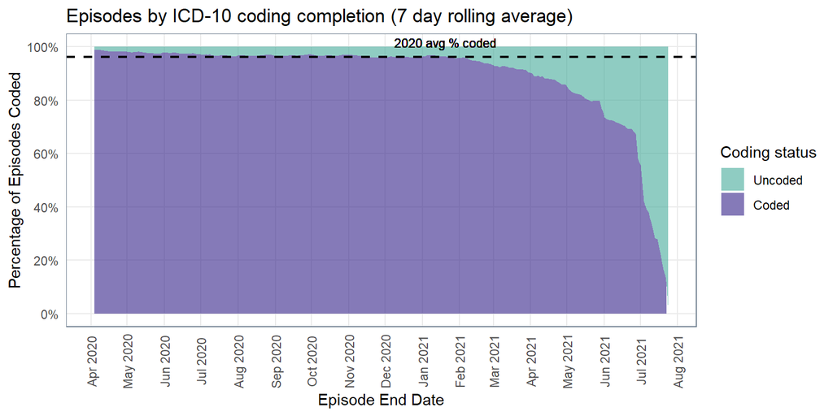

**Figure 14.** Episodes by coding completion (7 day rolling average)

The below chart shows the number of coded episodes ending on a given day. The area shading indicates the first data extract in which an ICD-10 code was recorded.

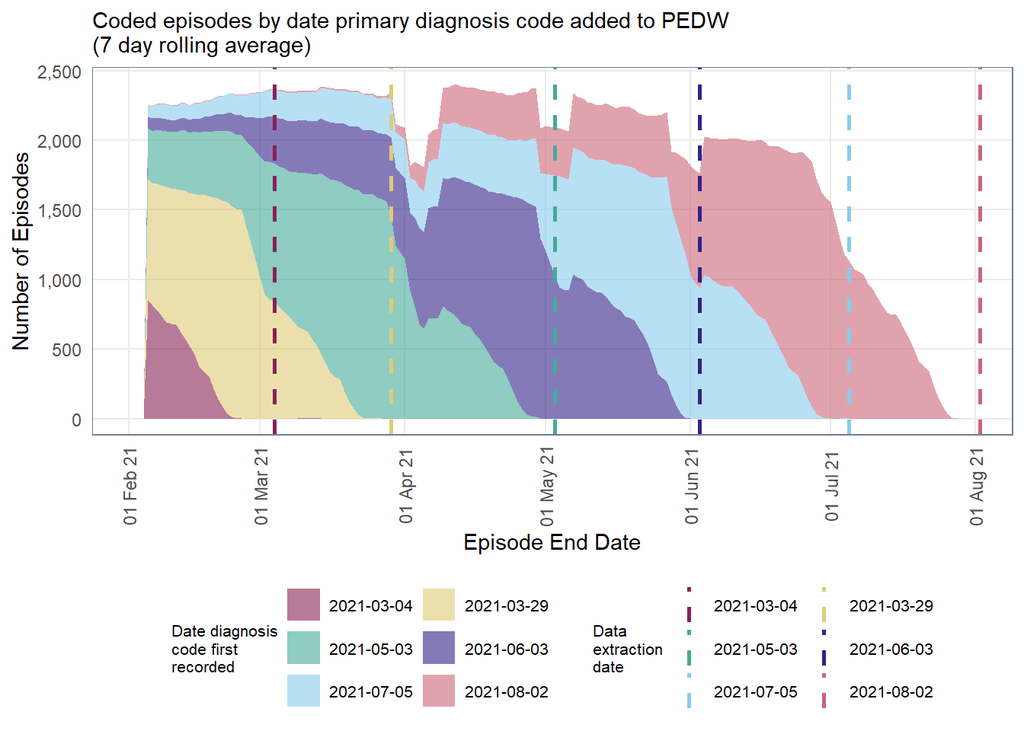

**Figure 15.** Primary diagnosis codes (ICD-10) by date added to PEDW (7 day rolling average)

The below chart shows the percentage of all episodes ending on a given day which had an ICD-10 code recorded. The area shading indicates the first data extract in which an ICD-10 coding was recorded.

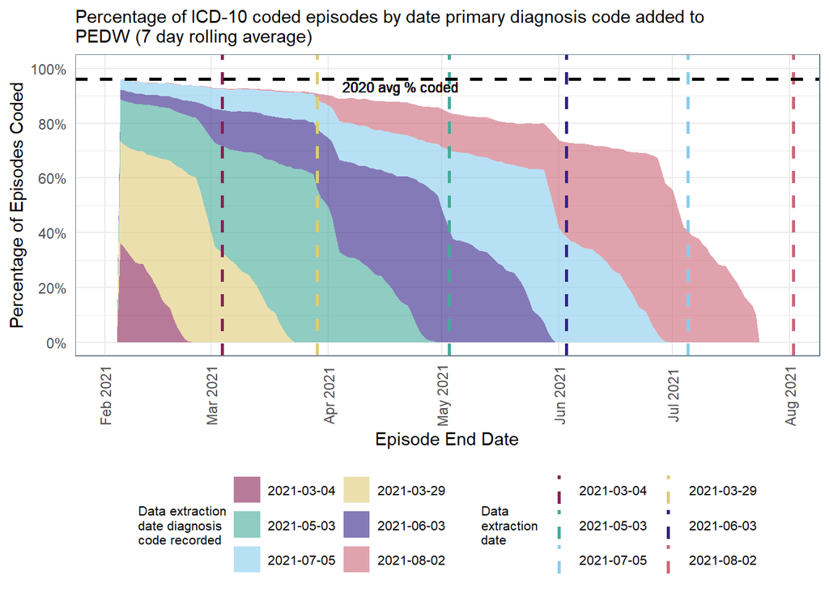

**Figure 16.** Percentage of coded episodes by date added to PEDW (7 day rolling average)

### Changes in primary ICD-10 diagnosis codes

Another form of data lag may occur when an episode has been recorded, but the diagnosis code has not been completed (uncoded episode) or the diagnosis code is subsequently updated.

In addition to the new episodes added to PEDW, there were 53,616 episodes where the primary diagnosis code had been added or updated since the 05 July 2021 PEDW data extract. The end dates for the revised episodes ranged from November 2016 to June 2021.

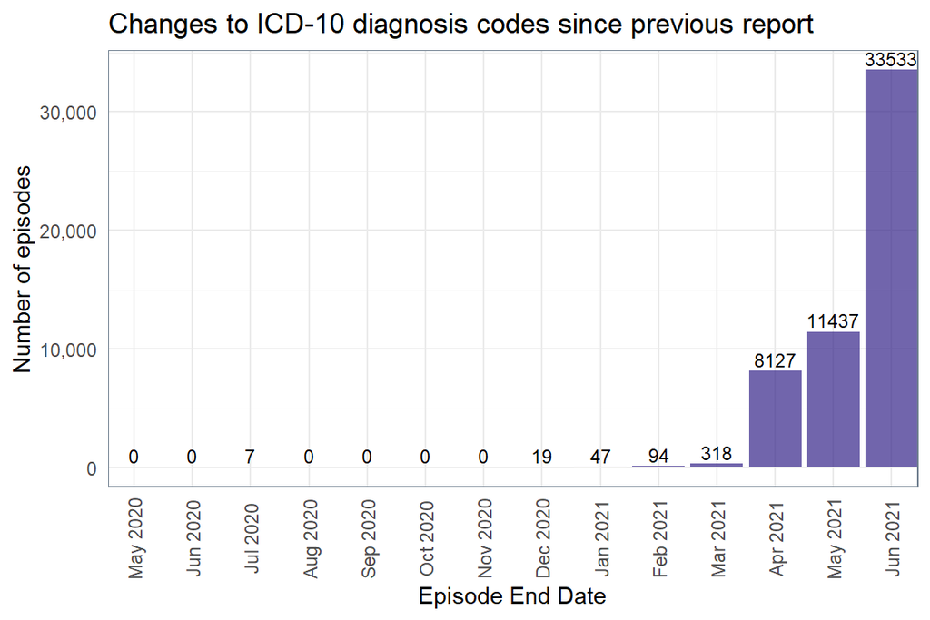

**Figure 17.** ICD-10 code changes since previous report end date by month of episode end

Of the 53,616 episodes which had a change to their primary ICD-10 diagnosis code since the previous report 100% ended within six months of the previous report.

The below chart illustrates this as a proportion of all episodes in PEDW

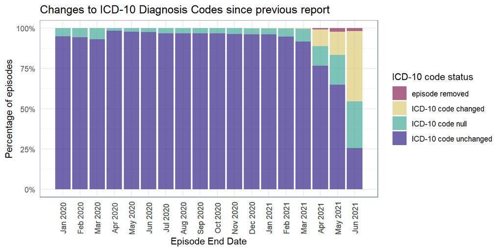

### ICD-10 Chapter Changes

Chapters 2 (neoplasms), 11 (diseases of the digestive system) and 18 (symptoms, signs and abnormal clinical and laboratory findings, not elsewhere classified) had the largest number of episodes with changes to their primary diagnosis codes between the 05 July 2021 data extract and the 02 August 2021 extract.

The below chord diagram shows all changes in primary ICD-10 codes by Chapter (see Appendix 1 for the ICD-10 Chapter descriptions)

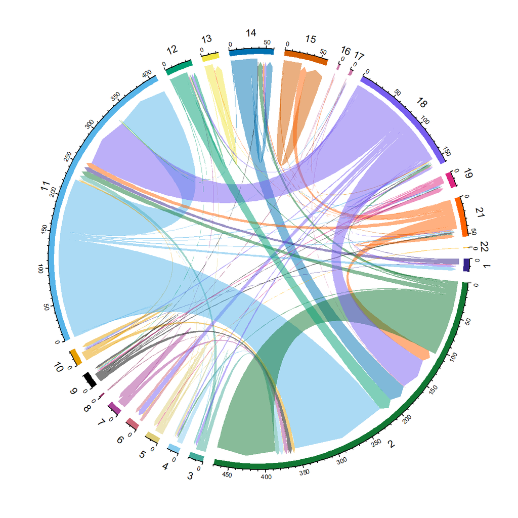

**Figure 19.** Changes between and within ICD-10 Chapters

The below chord diagram shows any changes from one ICD-10 Chapter to another (i.e. only when the ICD-10 code was between and not within Chapters).

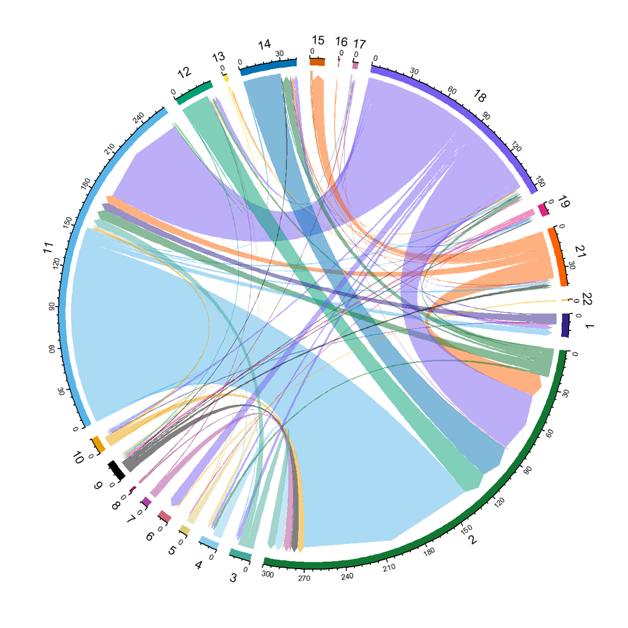

**Figure 20.** Changes between ICD-10 Chapters

### Analysis by ICD-10 Chapter

All Chapters experienced some disruption around April 2020. However, the amount of disruption and the subsequent recovery varied.

Note that chapters 8 and 17 have been excluded from the below charts prevent disclosure of small numbers.

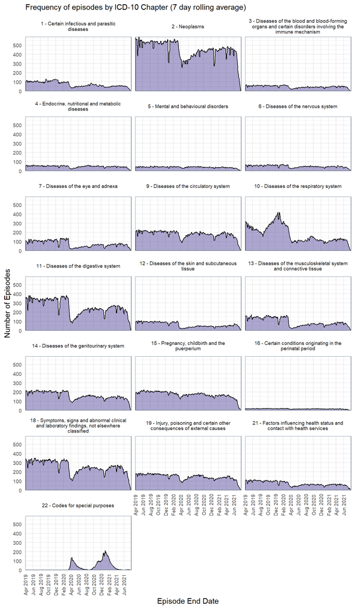

**Figure 21.** Episodes recorded by ICD-10 Chapter

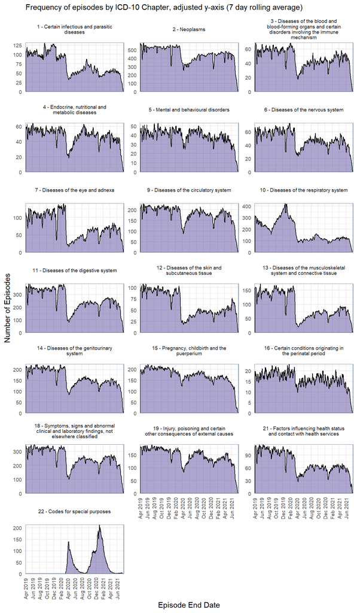

**Figure 22.** Episodes recorded by ICD-10 Chapter with free-y axis

**Table 5:** Average episodes Apr to Nov comparison 2019 to 2020

| Chapter number | 2019 mean eps. | 2020 mean eps. | Percentage change |
| --- | --- | --- | --- |
| 5 | 2635 | 2404 | -9% |
| 16 | 1128 | 952 | -16% |
| 9 | 11986 | 10012 | -16% |
| 4 | 3315 | 2769 | -16% |
| 15 | 12391 | 10312 | -17% |
| 19 | 10549 | 8367 | -21% |
| 2 | 32047 | 24045 | -25% |
| 6 | 3604 | 2579 | -28% |
| 14 | 12358 | 8547 | -31% |
| 18 | 19309 | 13282 | -31% |
| 3 | 3512 | 2319 | -34% |
| 11 | 19937 | 11952 | -40% |
| 21 | 6094 | 3354 | -45% |
| 1 | 6524 | 3425 | -47% |
| 17 | 617 | 300 | -51% |
| 7 | 6490 | 2804 | -57% |
| 10 | 16384 | 6983 | -57% |
| 12 | 5664 | 2403 | -58% |
| 13 | 8690 | 3483 | -60% |
| 8 | 839 | 298 | -64% |

Chapter 22 has been excluded from the 2020 comparison with previous averages because it reflects the COVID-19 diagnoses so there is no comparable figure prior to 2020.

All Chapters saw a reduction in the number of episodes in 2020 compared to the comparable period in 2019, but the extent of the reduction varied, from 9% to 64%. Chapter 8 (Diseases of the ear and mastoid process) showed the greatest reduction compared to the previous year, Chapter 5 (Mental and behavioural disorders) showed the least reduction and 6 Chapters more than halved the number of episodes recorded compared to the previous year.

Chapter 10 (diseases of the respiratory system), is one of the codes with the largest reduction in recorded episodes. Some of the serious symptoms of COVID-19 include difficulty breathing, shortness of breath and chest pain or pressure (World Health Organisation, 2021), so this change is explored further below.

### Analysis of ICD-10 respiratory codes

Episodes relating to respiratory diagnoses reduced in March at the same time that episodes with a COVID-19 diagnosis increased.

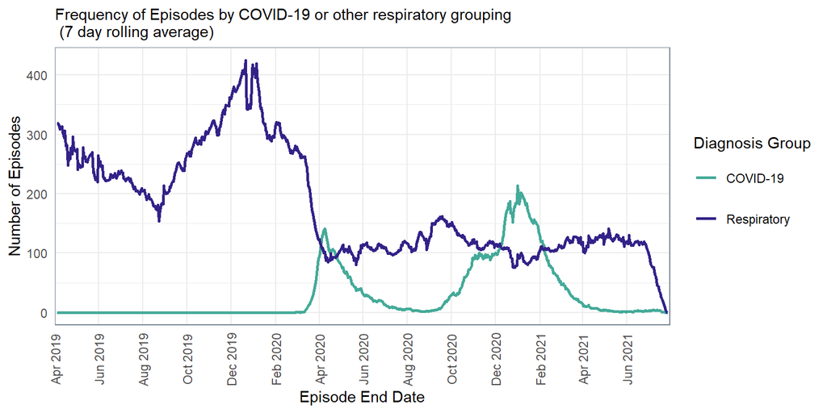

**Figure 23.** Frequency of respiratory diagnosis and covid diagnosis codes, 7 day rolling average

Respiratory episodes tend to show a cyclical pattern, with increased episodes occurring during the winter months. However, no such increase has yet been seen for winter 20/21.

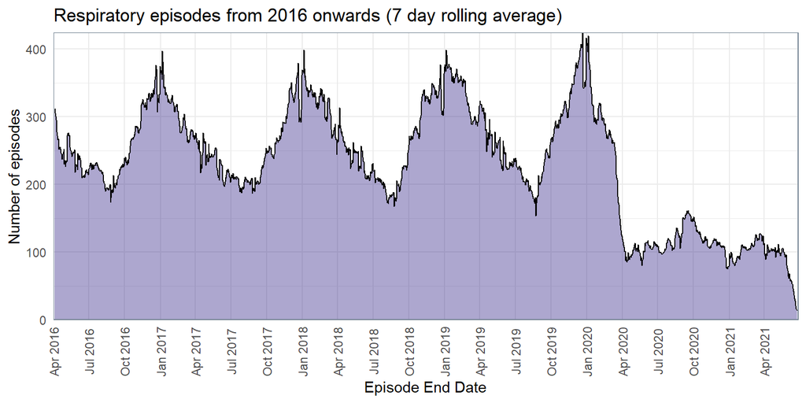

### Coding lag by ICD-10 chapter

The below charts show the number of coded episodes ending on a given day, displayed by ICD-10 Chapter. The area shading indicates the first data extract in which an ICD-10 coding was recorded.

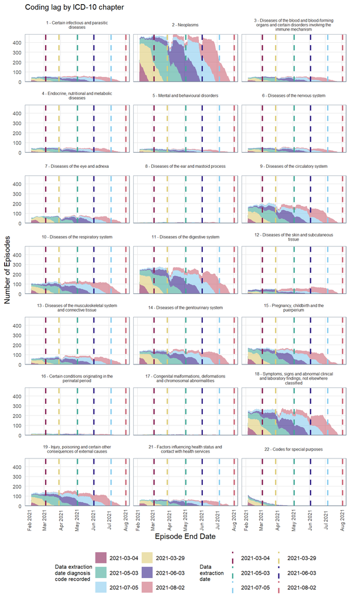

**Figure 25.** Coding lag by ICD-10 Chapter

Note that chapters 8 and 17 have been excluded from the below figures to prevent disclosure of small numbers.

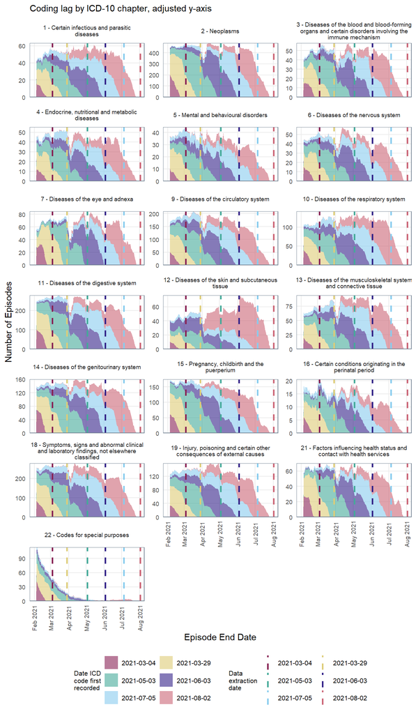

**Figure 26.** Coding lag by ICD-10 Chapter, adjusted y-axis

### Average number of diagnoses per episode

The average number of diagnoses recorded per episode has increased since April 2020, but shown a more recent reduction (likely due to data lag).

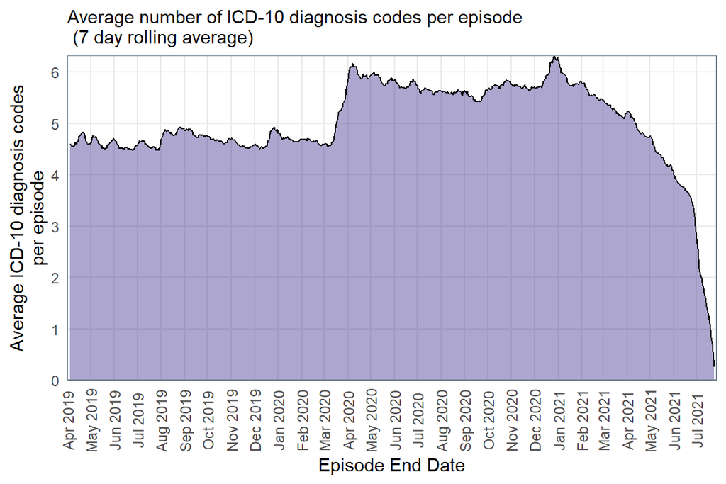

**Figure 27.** Average number of ICD-10 diagnosis codes recorded per episode

### Analysis by OPCS-4 Chapter

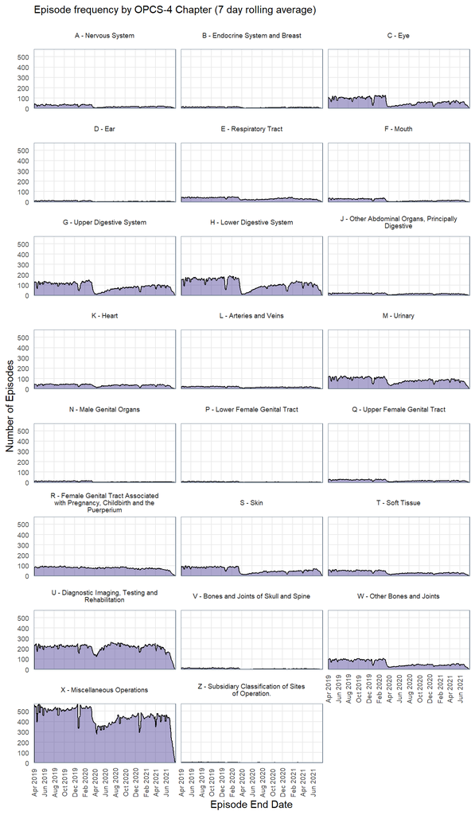

**Figure 28.** Episodes recorded by OPCS-4 Chapter, 7 day rolling average

Note that chapters B, D, F, J, N, P, V and Z have been excluded from the below figures to prevent disclosure of small numbers.

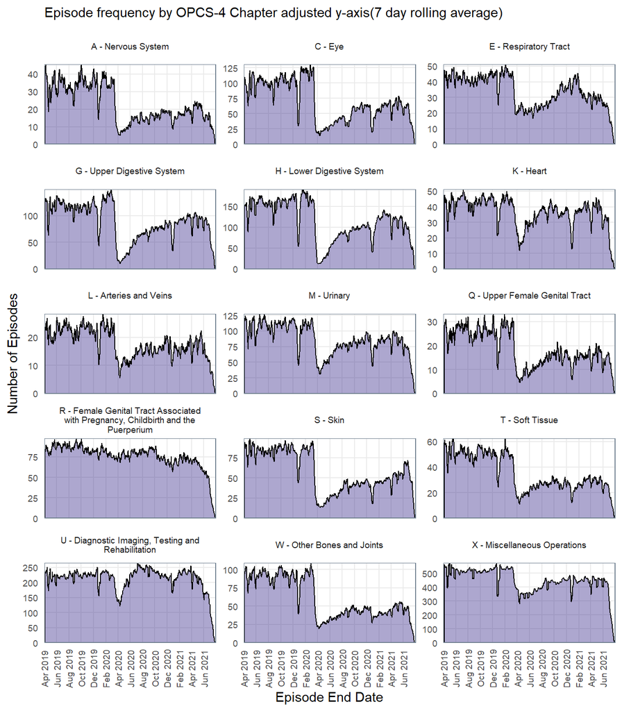

**Figure 29.** Episodes recorded by OPCS-4 Chapter, 7 day rolling average

**Table 6:** Average episodes Apr to Nov comparison 2019 to 2020

| OPCS-4 Chapter | 2019 mean eps. | 2020 mean eps. | Chapter description | Percentage change |
| --- | --- | --- | --- | --- |
| U | 6800 | 6739 | Diagnostic Imaging, Testing and Rehabilitation | -1% |
| R | 2628 | 2365 | Female Genital Tract Associated with Pregnancy, Childbirth and the Puerperium | -10% |
| X | 15714 | 12266 | Miscellaneous Operations | -22% |
| K | 1301 | 984 | Heart | -24% |
| J | 642 | 423 | Other Abdominal Organs, Principally Digestive | -34% |
| M | 3289 | 2159 | Urinary | -34% |
| E | 1294 | 839 | Respiratory Tract | -35% |
| L | 687 | 440 | Arteries and Veins | -36% |
| G | 3530 | 1772 | Upper Digestive System | -50% |
| B | 433 | 215 | Endocrine System and Breast | -50% |
| Q | 788 | 387 | Upper Female Genital Tract | -51% |
| T | 1560 | 744 | Soft Tissue | -52% |
| H | 4719 | 2223 | Lower Digestive System | -53% |
| Z | 166 | 70 | Subsidiary Classification of Sites of Operation. | -58% |
| W | 2785 | 1164 | Other Bones and Joints | -58% |
| C | 3047 | 1272 | Eye | -58% |
| A | 1041 | 428 | Nervous System | -59% |
| S | 2567 | 1022 | Skin | -60% |
| P | 222 | 75 | Lower Female Genital Tract | -66% |
| D | 332 | 101 | Ear | -70% |
| V | 352 | 104 | Bones and Joints of Skull and Spine | -70% |
| N | 361 | 106 | Male Genital Organs | -70% |
| F | 915 | 223 | Mouth | -76% |